# Bias correction assessment

Ruth Bowyer

2023-12-10

```r
rm(list=ls())

# install packages
list.of.packages <- c("ggplot2", "terra", "tmap", "RColorBrewer", "tidyverse", "kableExtra", "ncdf4", "knitr")
new.packages <- list.of.packages[!(list.of.packages %in% installed.packages()[,"Package"])]
if(length(new.packages)) install.packages(new.packages)
if (!require(devtools)) install.packages("devtools")
install_github("hzambran/hydroTSM")
install_github("hzambran/hydroGOF")

knitr::opts_knit$set(root.dir="/mnt/vmfileshare/ClimateData/")

# import packages
library(ggplot2)
library(terra)
library(tmap) #pretty maps
library(RColorBrewer)
library(tidyverse)
library(kableExtra)
library(ncdf4)
library(devtools)
```

## **0. About**

This is an example notebook for the assessment of bias corrected data, comparing it with our differing outputs from different methods across R and python.

**Calibration vs Validation dates**

We have used split sample testing of 30 years : 10 years for calibration and validation.

The calibration period runs between 01-12-1980 to the day prior to 01-12-2010 The validation period runs between 01-12-2010 to the day prior to 01-12-2020

**Data used in this script:**

Here we load data from **validation** period

The dates have been aligned manually and represent 3555 days whilst we fix a bug

```r
xx <- r.python[[1]]
rp <- xx[[1]]

ncin <- nc_open(rp)
time <- ncvar_get(ncin, "time")

missing <- c(0:3600)
tmissing <- missing %in% time

removethisindex <- missing[tmissing==F] + 1

removethisindex2 <- removethisindex[-c(1, 4, 8, 12, 52, 20, 24, 29, 34, 38, 44, 48, 56)]
```

```r
## The output created from the R bias correction framework is a list of dataframes containing all the data we need for this doc (although some are transposed).
rd <- "Debiased/R/QuantileMapping/three.cities/"

files <- list.files(paste0(dd,rd,city),full.names=T)
files.v <- files[grepl(var, files)]

allruns <- lapply(files.v, readRDS)

names <- gsub(paste0(dd,rd,city,"|/|.RDS"),"",files.v)
names(allruns) <- names

#This was returned for ease where multiple runs have been looped to apply this paritcular function, but actually we don't need a cope for each nor this data in a list. Therefore:
#obs.cal.df <- as.data.frame(t(allruns[[1]]$t.obs))

obs.val.df <- allruns[[1]]$val.df #To run between 1st Dec 2010 and 30th Nov 2020
obs.val.df <- obs.val.df[c(1:3600)]
obs.val.df <- obs.val.df[,-removethisindex2]

#In the R scirpt, the validation is corrected with the projected data as well - so needs to be seperated out (and transposed)
cpm.val.raw.df.L <- lapply(allruns, function(L){
  proj <- as.data.frame(t(L[["t.proj"]]))
 val.end.date <- min(grep("20201201-", names(proj)))-1
  cpm.val.raw.df <- proj[,1:(val.end.date-1)]
  cpm.val.raw.df <- cpm.val.raw.df[,-removethisindex2]
})



cpm.val.adj.df.L <- lapply(allruns, function(L){
  proj <- as.data.frame(t(L[["qm1.val.proj"]]))
  val.end.date <- min(grep("20201201-", names(proj)))-1
  proj[,1:val.end.date]
   cpm.val.adj.df <- proj[,1:(val.end.date-1)]
  cpm.val.adj.df <- cpm.val.adj.df[,-removethisindex2]
})


i <- obs.val.df
  rn <- row.names(i) #The rownames were saves as x_y coordinates
      xi <- gsub("_.*", "", rn)
      yi <- gsub(".*_", "", rn)
      xy <- data.frame(x = xi, y = yi)
      df <- cbind(xy, i)
      r <- rast(df, type="xyz")
      crs(r) <- crs
obs.val.rasts <- r


list2rast <- list(cpm.val.raw.df.L, cpm.val.adj.df.L)

rastsL <- lapply(list2rast, function(x){
  allruns <- x
  df.rL <- lapply(runs, function(i){
      df <- allruns[[grep(i, names(allruns))]] #extract df based on run id
      rn <- row.names(df) #The rownames were saves as x_y coordinates
      xi <- gsub("_.*", "", rn)
      yi <- gsub(".*_", "", rn)
      xy <- data.frame(x = xi, y = yi)
      df <- cbind(xy, df)
      r <- rast(df, type="xyz")
      crs(r) <- crs
      return(r)
      })
  names(df.rL) <- runs
  return(df.rL)
    })

names(rastsL) <- c("cpm.val.raw.rasts.L", "cpm.val.adj.rasts.L")

list2env(rastsL, .GlobalEnv)
```

```
## <environment: R_GlobalEnv>
```

```r
remove(rastsL)
remove(list2rast)

gc()
```

```
##            used (Mb) gc trigger  (Mb) max used  (Mb)
## Ncells  3574880  191    6358087 339.6  6358087 339.6
## Vcells 42063927  321   73809384 563.2 61441141 468.8
```

```r
obsL <- list(obs.val.df, obs.val.rasts)
names(obsL) <- c("observation.df", "observation.rasts")

cpm.raw <- lapply(1:4, function(i){
  rast1 <- cpm.val.raw.rasts.L[[i]]
  df1 <- cpm.val.raw.df.L[[i]]
  l <- list(rast1, df1)
  names(l) <- c("rast", "df")
  return(l)
  })

names(cpm.raw) <- paste0("cpm_raw_Run", names(cpm.val.raw.rasts.L))

cpm.adj <- lapply(1:4, function(i){
  rast1 <- cpm.val.adj.rasts.L[[i]]
  df1 <- cpm.val.adj.df.L[[i]]
  l <- list(rast1, df1)
  names(l) <- c("rast", "df")
  return(l)
  })

names(cpm.adj) <- paste0("cpm_R_quantilemapping_Run", names(cpm.val.adj.rasts.L))
```

```r
names(cpm.adj) <- paste0("r.quantile_Run", names(cpm.val.adj.rasts.L))

dataL <- c(obsL, cpm.raw, val_py, cpm.adj)
```

## **1. Bias Correction Assessment: trends**

A visual comparison of trends across observation, raw and adjusted data for the same time period

### **1a. Raster comparison**

A visualisation across different runs and methods

Adding in the city shapeoutline for prettier maps

```r
shape <-sf::st_as_sf(vect(paste0(dd, "shapefiles/three.cities/", city, "/", city, ".shp")))
```

## **Compare across the same day**

Here we take a day and visualise the differences between the methods and runs

The example below is set up to compare Run 05, but Run 06, 07 or 08 can all be compared

Choose a day between 1 - 3555 You can change the Run in the code below

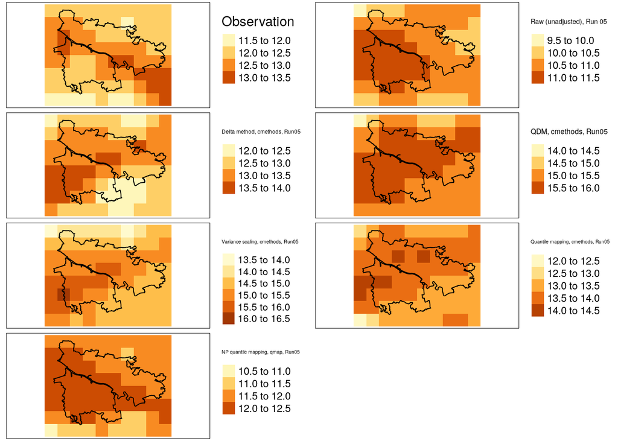

```r
day <- 1777

t1 <- tm_shape(dataL$observation.rasts[[day]]) +
  tm_raster(title="Observation") +
  tm_layout(legend.outside = T) +
  tm_shape(shape) +
  tm_borders(col="black")


t2 <- tm_shape(dataL$cpm_raw_Run05$rast[[day]]) +
  tm_raster(title="Raw (unadjusted), Run 05") +
  tm_layout(legend.outside = T) +
  tm_shape(shape) +
  tm_borders(col="black")

t3 <- tm_shape(dataL$python_runs05$py.delta_method$rast[[day]]) +
  tm_raster(title="Delta method, cmethods, Run05") +
  tm_layout(legend.outside = T) +
  tm_shape(shape) +
  tm_borders(col="black")

t4 <- tm_shape(dataL$python_runs05$py.quantile_delta$rast[[day]]) +
  tm_raster(title="QDM, cmethods, Run05") +
  tm_layout(legend.outside = T) +
  tm_shape(shape) +
  tm_borders(col="black")

t5 <- tm_shape(dataL$python_runs05$py.var_scaling$rast[[day]]) +
  tm_raster(title="Variance scaling, cmethods, Run05") +
  tm_layout(legend.outside = T) +
  tm_shape(shape) +
  tm_borders(col="black")

t6 <- tm_shape(dataL$python_runs05$py.quantile$rast[[day]]) +
  tm_raster(title="Quantile mapping, cmethods, Run05") +
  tm_layout(legend.outside = T) +
  tm_shape(shape) +
  tm_borders(col="black")


t7 <- tm_shape(dataL$r.quantile_Run05$rast[[day]]) +
  tm_raster(title="NP quantile mapping, qmap, Run05") +
  tm_layout(legend.outside = T) +
  tm_shape(shape) +
  tm_borders(col="black")


tmap_arrange(t1, t2, t3, t4, t5, t6, t7,  nrow = 4)
```

## **2. Bias Correction Assessment: Metrics**

We use Run 05 again here, but you could change the run in the code below to see how it effects the outcome

```r
val.dfs <- list(dataL$observation.df,
                dataL$cpm_raw_Run05$df,
                dataL$python_runs05$py.delta_method$df,
                dataL$python_runs05$py.quantile_delta$df,
                dataL$python_runs05$py.quantile$df,
                dataL$python_runs05$py.var_scaling$df,
                dataL$r.quantile_Run05$df)

#Convert dfs to a vector
val.dfs.v <- lapply(val.dfs, function(d){
  #Convert to single vector
  unlist(as.vector(d))})

val.dfs.v.df <- as.data.frame(val.dfs.v)

names <-  c("Obs","Raw_Run05", "Delta_mapping_cmethods_Run05", "QDM_cmethods_Run05",
                         "QM_cmethods_Run05","Var_scaling_cmethods_Run05", "QM_qmap_Run05")
names(val.dfs.v.df) <- names
```

### **2a. Descriptive statistics**

```r
descriptives <- apply(val.dfs.v.df, 2, function(x){
  per <- data.frame(as.list(quantile(x, probs=c(0.1, 0.9))))
  data.frame(mean=mean(x), sd=sd(x), min = min(x), per10th=per$X10.,per90th=per$X90., max = max(x))
})

descriptives <- descriptives %>% reduce(rbind)
row.names(descriptives) <- names(val.dfs.v.df)
d <- t(descriptives)

d %>%
  kable(booktabs = T) %>%
  kable_styling()
```

|  | Obs | Raw_Run05 | Delta_mapping_cmethods_Run05 | QDM_cmethods_Run05 | QM_cmethods_Run05 | Var_scaling_cmethods_Run05 | QM_qmap_Run05 |
| --- | --- | --- | --- | --- | --- | --- | --- |
| mean | 12.987187 | 12.454529 | 13.206697 | 14.354030 | 12.446912 | 13.6338065 | 13.546393 |
| sd | 5.379666 | 5.985046 | 5.580365 | 5.682610 | 5.983804 | 5.4667575 | 5.555303 |
| min | -5.222516 | -3.289649 | -6.927810 | -3.942330 | -3.289649 | -0.0068817 | -2.261268 |
| per10th | 6.004220 | 4.400269 | 5.983167 | 6.595541 | 4.407593 | 6.4332728 | 6.496371 |
| per90th | 19.933914 | 20.196924 | 20.189136 | 21.603798 | 20.196924 | 20.7896622 | 20.831031 |
| max | 31.605967 | 32.398094 | 32.394508 | 33.386124 | 32.398094 | 34.7932587 | 34.132040 |

#### Fig.Density plot of validation period

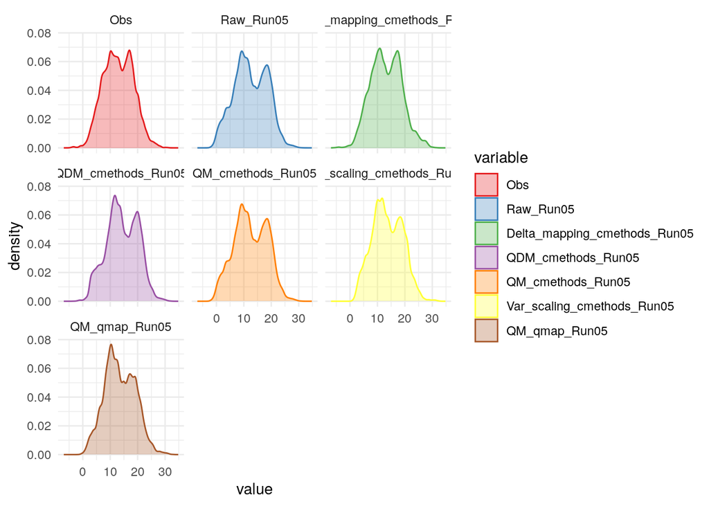

```r
m <- reshape2::melt(val.dfs.v.df)

ggplot(m, aes(value, fill=variable, colour=variable)) +
  geom_density(alpha = 0.3, position="identity") +
  theme_minimal() +
  scale_fill_brewer(palette = "Set1") +
  scale_color_brewer(palette = "Set1") +
  facet_wrap(.~variable)
```

#### Seasonal

```r
# Using the 360 year structure, derive row indexes for each of the seasons, assuming the first calendar date represents Dec 1st

winter <- c(1:90)
for(i in 1:8){
  x <-1 + i*360
  y <-1 + i*360 + 90 #60 days is 3 months
  winter <- c(winter, x:y)
}

winter <- winter[!winter%in%removethisindex2]

spring <- c(91:180)
for(i in 1:8){
  x <-91 + (i*360)
  y <-91 + (i*360) + 90 #90 days is 3 months
  sping <- c(spring, x:y)
}
spring <- spring[!spring%in%removethisindex2]

summer <- c(181:270)
for(i in 1:8){
  x <- 181 + (i*360)
  y <- 181 + i*360 + 60 #60 days is 3 months
  summer <- c(summer, x:y)
}

summer <- summer[!summer%in%removethisindex2]

autumn <- c(271:360)
for(i in 1:8){
  x <- 181 + (i*360)
  y <- 181 + i*360 + 60 #60 days is 3 months
  autumn <- c(autumn, x:y)
}

autumn <- autumn[!autumn%in%removethisindex2]

seasons <- list(winter, spring, summer, autumn)
```

```r
seasonal.descriptives <- lapply(seasons, function(s){

#Convert dfs to a vector
df<- lapply(val.dfs, function(d){
    #Convert to single vector with just the seasonally defined columns
  d <- d[,s]
  unlist(as.vector(d))})

df <- as.data.frame(df)

  names(df) <- names

  descriptives <- apply(df, 2, function(x){
    per <- data.frame(as.list(quantile(x, probs=c(0.1, 0.9))))
    data.frame(mean=mean(x), sd=sd(x), min = min(x), per10th=per$X10.,per90th=per$X90., max = max(x))
  })

  descriptives <- descriptives %>% reduce(rbind)
  row.names(descriptives) <- names(df)
  d <- t(descriptives)
})
```

#### Winter

```r
seasonal.descriptives[[1]] %>%
    kable(booktabs = T) %>%
    kable_styling()
```

|  | Obs | Raw_Run05 | Delta_mapping_cmethods_Run05 | QDM_cmethods_Run05 | QM_cmethods_Run05 | Var_scaling_cmethods_Run05 | QM_qmap_Run05 |
| --- | --- | --- | --- | --- | --- | --- | --- |
| mean | 7.545045 | 6.531616 | 7.477307 | 8.740652 | 6.540570 | 8.3213606 | 8.140226 |
| sd | 3.161591 | 3.510415 | 3.251183 | 3.544761 | 3.512938 | 3.0433078 | 3.162931 |
| min | -5.222516 | -3.289649 | -6.927810 | -3.942330 | -3.289649 | -0.0068817 | -2.261268 |
| per10th | 3.395401 | 1.345557 | 3.180538 | 3.511754 | 1.329981 | 3.8597124 | 3.401121 |
| per90th | 11.369810 | 10.873218 | 11.344628 | 12.974035 | 10.862696 | 12.0620594 | 11.981927 |
| max | 18.378738 | 14.865137 | 19.443403 | 16.748768 | 14.865137 | 16.5707417 | 15.496591 |

#### Spring

```r
seasonal.descriptives[[2]] %>%
    kable(booktabs = T) %>%
    kable_styling()
```

|  | Obs | Raw_Run05 | Delta_mapping_cmethods_Run05 | QDM_cmethods_Run05 | QM_cmethods_Run05 | Var_scaling_cmethods_Run05 | QM_qmap_Run05 |
| --- | --- | --- | --- | --- | --- | --- | --- |
| mean | 13.409216 | 11.0399991 | 13.767192 | 13.033342 | 10.9968695 | 12.956441 | 12.192291 |
| sd | 3.698367 | 4.3338851 | 3.748335 | 4.149504 | 4.3766697 | 4.330499 | 3.934073 |
| min | 2.120107 | 0.1720215 | 3.540063 | 2.777159 | 0.1720215 | 2.550656 | 1.889193 |
| per10th | 8.211545 | 5.6897948 | 8.923459 | 7.695422 | 5.4196288 | 7.495068 | 7.579992 |
| per90th | 18.027275 | 17.0698734 | 18.580704 | 18.692587 | 17.0698734 | 18.972151 | 17.462591 |
| max | 21.960329 | 25.3600101 | 21.897438 | 26.726339 | 25.3600101 | 26.338200 | 26.581937 |

#### Summer

```r
seasonal.descriptives[[3]] %>%
    kable(booktabs = T) %>%
    kable_styling()
```

|  | Obs | Raw_Run05 | Delta_mapping_cmethods_Run05 | QDM_cmethods_Run05 | QM_cmethods_Run05 | Var_scaling_cmethods_Run05 | QM_qmap_Run05 |
| --- | --- | --- | --- | --- | --- | --- | --- |
| mean | 18.885843 | 19.668851 | 19.414031 | 21.138834 | 19.673040 | 20.249657 | 20.356901 |
| sd | 2.844915 | 2.860375 | 3.154909 | 2.730936 | 2.862330 | 3.078232 | 3.133506 |
| min | 9.794850 | 9.882959 | 11.033133 | 12.156556 | 9.882959 | 9.117639 | 11.233149 |
| per10th | 15.730152 | 16.361451 | 15.923339 | 17.986867 | 16.331885 | 16.637978 | 16.800074 |
| per90th | 22.770690 | 23.189868 | 24.174515 | 24.504973 | 23.189868 | 24.042363 | 24.335204 |
| max | 31.013290 | 32.398094 | 30.361607 | 33.386124 | 32.398094 | 34.793259 | 34.132040 |

#### Autumn

```r
seasonal.descriptives[[4]] %>%
    kable(booktabs = T) %>%
    kable_styling()
```

|  | Obs | Raw_Run05 | Delta_mapping_cmethods_Run05 | QDM_cmethods_Run05 | QM_cmethods_Run05 | Var_scaling_cmethods_Run05 | QM_qmap_Run05 |
| --- | --- | --- | --- | --- | --- | --- | --- |
| mean | 18.196291 | 18.681650 | 18.391090 | 20.213214 | 18.679398 | 19.268436 | 19.423338 |
| sd | 3.564522 | 4.108216 | 4.271161 | 3.895637 | 4.131500 | 4.192679 | 4.152337 |
| min | 1.543686 | 2.619775 | 2.361020 | 4.513280 | 2.619775 | 4.586860 | 4.605356 |
| per10th | 14.272142 | 14.116602 | 12.865782 | 15.899373 | 14.074073 | 14.308384 | 14.893791 |
| per90th | 22.662147 | 23.006763 | 24.122185 | 24.306695 | 23.006763 | 23.855662 | 24.109881 |
| max | 31.013290 | 32.398094 | 30.361607 | 33.386124 | 32.398094 | 34.793259 | 34.132040 |

### **2b. Model fit statistics**

Using the following to assess overall fit:

- **R-squared (rsq)**
- **Root Square Mean Error (RMSE)**
- **Nash-Sutcliffe Efficiency (NSE):** Magnitude of residual variance compared to measured data variance, ranges -∞ to 1, 1 = perfect match to observations
- **Percent bias (PBIAS):** The optimal value of PBIAS is 0.0, with low-magnitude values indicating accurate model simulation. Positive values indicate overestimation bias, whereas negative values indicate model underestimation bias.

```r
actual <- val.dfs.v.df$Obs

rsq <- sapply(val.dfs.v.df[c(2:ncol(val.dfs.v.df))], function(x){
  cor(actual, x)^2
})

rmse <- sapply(val.dfs.v.df[c(2:ncol(val.dfs.v.df))], function(x){
  sqrt(mean((actual - x)^2))
})


pbias <- sapply(val.dfs.v.df[c(2:ncol(val.dfs.v.df))], function(x){
  hydroGOF::pbias(x, actual)
})


nse <- sapply(val.dfs.v.df[c(2:ncol(val.dfs.v.df))], function(x){
  hydroGOF::NSE(x, actual)
})


k <- cbind(rsq, rmse, pbias, nse)
k %>%
  kable(booktabs = T) %>%
  kable_styling()
```

|  | rsq | rmse | pbias | nse |
| --- | --- | --- | --- | --- |
| Raw_Run05 | 0.5547920 | 4.132913 | -4.1 | 0.4097943 |
| Delta_mapping_cmethods_Run05 | 0.5206012 | 4.099781 | 1.7 | 0.4192192 |
| QDM_cmethods_Run05 | 0.5431828 | 4.247295 | 10.5 | 0.3766733 |
| QM_cmethods_Run05 | 0.5499737 | 4.158476 | -4.2 | 0.4024705 |
| Var_scaling_cmethods_Run05 | 0.5406815 | 3.999291 | 5.0 | 0.4473414 |
| QM_qmap_Run05 | 0.5457176 | 3.995015 | 4.3 | 0.4485227 |

#### Seasonal

```r
seasonal.model.stats <- lapply(seasons, function(s){

  #Convert dfs to a vector
  df<- lapply(val.dfs, function(d){

  #Convert to single vector with just the seasonally defined columns
  d <- d[,s]
  unlist(as.vector(d))})

  df <- as.data.frame(df)
  names(df) <- names

  actual <- df$Obs

  rsq <- sapply(df[c(2:ncol(df))], function(x){
    cor(actual, x)^2
  })


  rmse <- sapply(df[c(2:ncol(df))], function(x){
    sqrt(mean((actual - x)^2))
  })


  pbias <- sapply(df[c(2:ncol(df))], function(x){
    hydroGOF::pbias(x, actual)
  })


  nse <- sapply(df[c(2:ncol(df))], function(x){
    hydroGOF::NSE(x, actual)
  })

  k <- cbind(rsq, rmse, pbias, nse)})
```

Highlighting the bias corrected statistics

#### Winter

```r
seasonal.model.stats[[1]]  %>%
  kable(booktabs = T) %>%
  kable_styling()
```

|  | rsq | rmse | pbias | nse |
| --- | --- | --- | --- | --- |
| Raw_Run05 | 0.0170801 | 4.521556 | -13.4 | -1.0453669 |
| Delta_mapping_cmethods_Run05 | 0.0007238 | 4.474042 | -0.9 | -1.0026056 |
| QDM_cmethods_Run05 | 0.0178275 | 4.582295 | 15.8 | -1.1006881 |
| QM_cmethods_Run05 | 0.0177739 | 4.514827 | -13.3 | -1.0392835 |
| Var_scaling_cmethods_Run05 | 0.0190308 | 4.147905 | 10.3 | -0.7212862 |
| QM_qmap_Run05 | 0.0180254 | 4.203405 | 7.9 | -0.7676566 |

#### Spring

```r
seasonal.model.stats[[2]]  %>%
  kable(booktabs = T) %>%
  kable_styling()
```

|  | rsq | rmse | pbias | nse |
| --- | --- | --- | --- | --- |
| Raw_Run05 | 0.0597691 | 5.498464 | -17.7 | -1.2106695 |
| Delta_mapping_cmethods_Run05 | 0.0579244 | 4.602206 | 2.7 | -0.5487213 |
| QDM_cmethods_Run05 | 0.0590227 | 4.855678 | -2.8 | -0.7240140 |
| QM_cmethods_Run05 | 0.0581359 | 5.553689 | -18.0 | -1.2552995 |
| Var_scaling_cmethods_Run05 | 0.0634245 | 4.956393 | -3.4 | -0.7962737 |
| QM_qmap_Run05 | 0.0608302 | 4.843107 | -9.1 | -0.7150988 |

#### Summer

```r
seasonal.model.stats[[3]]  %>%
  kable(booktabs = T) %>%
  kable_styling()
```

|  | rsq | rmse | pbias | nse |
| --- | --- | --- | --- | --- |
| Raw_Run05 | 0.0000367 | 4.097490 | 4.1 | -1.0744674 |
| Delta_mapping_cmethods_Run05 | 0.0642809 | 3.711397 | 2.8 | -0.7019451 |
| QDM_cmethods_Run05 | 0.0008483 | 4.591269 | 11.9 | -1.6045713 |
| QM_cmethods_Run05 | 0.0007039 | 4.163879 | 4.2 | -1.1422337 |
| Var_scaling_cmethods_Run05 | 0.0001434 | 4.431523 | 7.2 | -1.4264800 |
| QM_qmap_Run05 | 0.0000007 | 4.482345 | 7.8 | -1.4824546 |

#### Autumn

```r
seasonal.model.stats[[4]]  %>%
  kable(booktabs = T) %>%
  kable_styling()
```

|  | rsq | rmse | pbias | nse |
| --- | --- | --- | --- | --- |
| Raw_Run05 | 0.1869855 | 4.141732 | 2.7 | -0.3501154 |
| Delta_mapping_cmethods_Run05 | 0.2960919 | 3.797036 | 1.1 | -0.1347399 |
| QDM_cmethods_Run05 | 0.1724539 | 4.518442 | 11.1 | -0.6068830 |
| QM_cmethods_Run05 | 0.1770343 | 4.197067 | 2.7 | -0.3864324 |
| Var_scaling_cmethods_Run05 | 0.1650665 | 4.392008 | 5.9 | -0.5182142 |
| QM_qmap_Run05 | 0.1603198 | 4.427219 | 6.7 | -0.5426548 |